# lab6_zimengd

## Exercise 1

# 1

What is the correlation between Ozone and Wind? Please describe the meaning of this correlation value in non-technical terms (e.g., as Ozone increases, Wind.). In your opinion, is this a strong correlation?

# 2

What is the correlation between Ozone and Solar.R? Please describe the meaning of this correlation value in non-technical terms. In your opinion, is this a strong correlation?

The correlation between Ozone and Solar.R is 0.3483417. As Ozone increases 1unit, Solar.R increases 0.3483417 unit. I do not think it’s a strong correlation.

## Exercise 2 (R code and outputs required)

# 1

Plot the waiting time between eruptions (waiting) against the duration of the eruption (eruptions) for the Old Faithful geyser in Yellowstone National Park. The dataset is built in R and is named faithful.

```r
head(faithful)
```

```
##   eruptions waiting
## 1     3.600      79
## 2     1.800      54
## 3     3.333      74
## 4     2.283      62
## 5     4.533      85
## 6     2.883      55
```

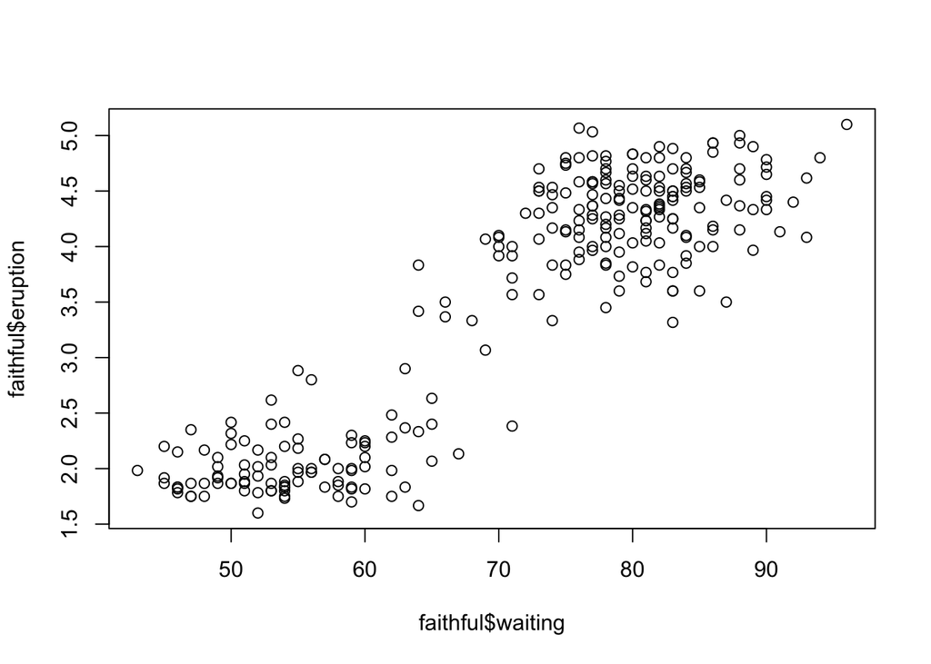

```r
plot(faithful$eruption~ faithful$waiting)
```

# 2

Calculate the correlation coefficient between the waiting time (waiting) and duration of eruption (eruptions).

```r
cor(faithful$waiting, faithful$eruption, use = 'complete.obs')
```

```
## [1] 0.9008112
```

## Exercise 3 (R code and outputs required)

# 1

Build a second linear model using Temp as your dependent variable and Ozone as your independent variable. Interpret your linear model results. Plot a scatterplot of your variables with an estimated regression line.

```r
mod <- lm(Temp ~ Ozone, data = airquality)
summary(mod)
```

```
##
## Call:
## lm(formula = Temp ~ Ozone, data = airquality)
##
## Residuals:
##     Min      1Q  Median      3Q     Max
## -22.147  -4.858   1.828   4.342  12.328
##
## Coefficients:
##             Estimate Std. Error t value Pr(>|t|)
## (Intercept) 69.41072    1.02971   67.41   <2e-16 ***
## Ozone        0.20081    0.01928   10.42   <2e-16 ***
## ---
## Signif. codes:  0 '***' 0.001 '**' 0.01 '*' 0.05 '.' 0.1 ' ' 1
##
## Residual standard error: 6.819 on 114 degrees of freedom
##   (37 observations deleted due to missingness)
## Multiple R-squared:  0.4877, Adjusted R-squared:  0.4832
## F-statistic: 108.5 on 1 and 114 DF,  p-value: < 2.2e-16
```

p-value is 2.2e-16 which is below 0.05. So the corelationship between temperature and ozone is significant. When ozone increase 1 unit, temperature increases 0.20081 unit. When ozone is zero, temperature is estimated to be 69.41072.

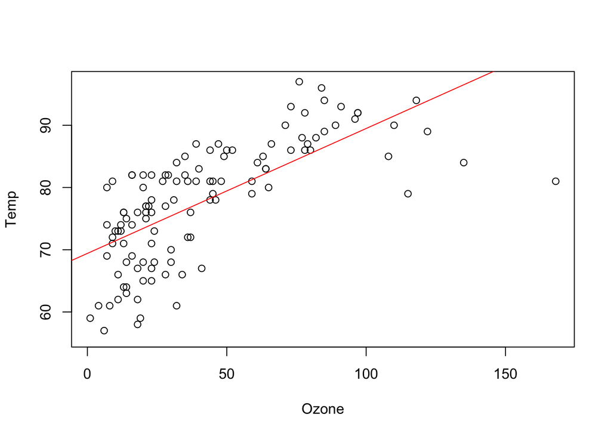

```r
plot(Temp ~ Ozone, data = airquality)
abline(lm(Temp ~ Ozone, data = airquality), col = "red")
```

# 2

Build a third linear model using the faithful dataset to examine if you see longer erruption times if you wait longer. Interpret your linear model results. Plot a scatterplot of your variables with an estimated regression line.

```r
mod <- lm(eruptions ~ waiting, data = faithful)
summary(mod)
```

```
##
## Call:
## lm(formula = eruptions ~ waiting, data = faithful)
##
## Residuals:
##      Min       1Q   Median       3Q      Max
## -1.29917 -0.37689  0.03508  0.34909  1.19329
##
## Coefficients:
##              Estimate Std. Error t value Pr(>|t|)
## (Intercept) -1.874016   0.160143  -11.70   <2e-16 ***
## waiting      0.075628   0.002219   34.09   <2e-16 ***
## ---
## Signif. codes:  0 '***' 0.001 '**' 0.01 '*' 0.05 '.' 0.1 ' ' 1
##
## Residual standard error: 0.4965 on 270 degrees of freedom
## Multiple R-squared:  0.8115, Adjusted R-squared:  0.8108
## F-statistic:  1162 on 1 and 270 DF,  p-value: < 2.2e-16
```

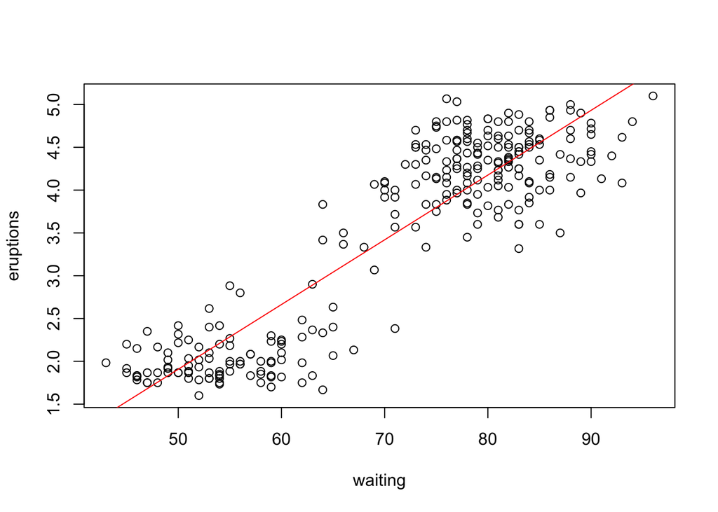

```r
plot(eruptions ~ waiting, data = faithful)
abline(lm(eruptions ~ waiting, data = faithful), col = "red")
```

## Exercise 4 (R code and outputs required)

# 1

Remember that SSY is comprised of both SSYp (SSY’) and SSE. Please calculate SSE. I know this may be hard, but you can do it! Then, verify that SSY - SSYp is equal to SSE. What is SSE measuring in non-technical terms?

```r
mod <- lm(Temp ~ Wind, data = airquality)
summary(mod)
```

```
##
## Call:
## lm(formula = Temp ~ Wind, data = airquality)
##
## Residuals:
##     Min      1Q  Median      3Q     Max
## -23.291  -5.723   1.709   6.016  19.199
##
## Coefficients:
##             Estimate Std. Error t value Pr(>|t|)
## (Intercept)  90.1349     2.0522  43.921  < 2e-16 ***
## Wind         -1.2305     0.1944  -6.331 2.64e-09 ***
## ---
## Signif. codes:  0 '***' 0.001 '**' 0.01 '*' 0.05 '.' 0.1 ' ' 1
##
## Residual standard error: 8.442 on 151 degrees of freedom
## Multiple R-squared:  0.2098, Adjusted R-squared:  0.2045
## F-statistic: 40.08 on 1 and 151 DF,  p-value: 2.642e-09
```

```r
r2 <- summary(mod)$r.squared
```

```r
y <- airquality$Temp
meany <- mean(y)
diff <- y - meany
SSY <- sum(diff^2)
```

```r
x <- data.frame(Wind = airquality$Wind)
predy <- predict.lm(mod,x)
meany <- mean(y)
diff <- predy - meany
SSYp <- sum(diff^2)
```

```r
diff <- y - predy
SSE <- sum(diff^2)
SSE
```

```
## [1] 10761.49
```

```r
SSE <- SSY - SSYp
SSE
```

```
## [1] 10761.49
```

SSE(error sum of squares) measures the square of difference in y and predicted y which is the part can not be explained by the variation of the predicted variable.

## Exercise 5 (R code and outputs required)

# 1

Create a linear model using the airquality dataset with Temp as your dependent variable and Ozone as your independent variable. Check and comment on whether your model meets the assumptions of homoscedasticity and normality using the plots and tests we used above.

# homoscedasticity

```r
mod <- lm(Temp ~ Ozone, data = airquality)
summary(mod)
```

```
##
## Call:
## lm(formula = Temp ~ Ozone, data = airquality)
##
## Residuals:
##     Min      1Q  Median      3Q     Max
## -22.147  -4.858   1.828   4.342  12.328
##
## Coefficients:
##             Estimate Std. Error t value Pr(>|t|)
## (Intercept) 69.41072    1.02971   67.41   <2e-16 ***
## Ozone        0.20081    0.01928   10.42   <2e-16 ***
## ---
## Signif. codes:  0 '***' 0.001 '**' 0.01 '*' 0.05 '.' 0.1 ' ' 1
##
## Residual standard error: 6.819 on 114 degrees of freedom
##   (37 observations deleted due to missingness)
## Multiple R-squared:  0.4877, Adjusted R-squared:  0.4832
## F-statistic: 108.5 on 1 and 114 DF,  p-value: < 2.2e-16
```

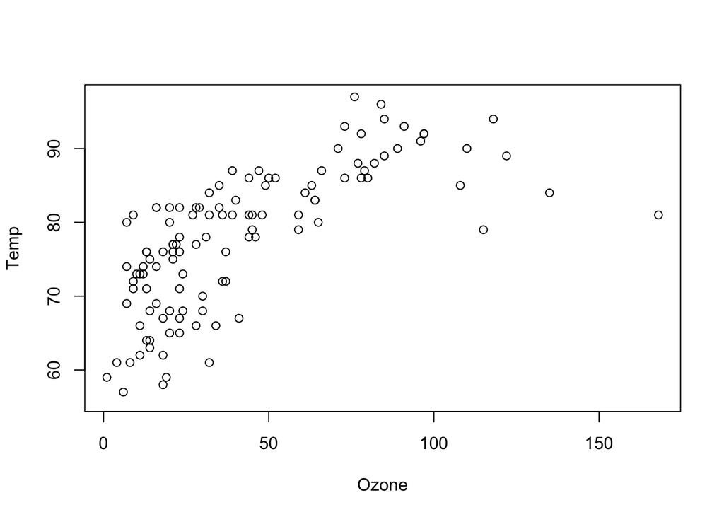

```r
plot(Temp ~ Ozone, data = airquality)
```

```r
#install.packages('lmtest')
#install.packages('car')
library(lmtest)
library(car)
bptest(mod)
```

```
##
##  studentized Breusch-Pagan test
##
## data:  mod
## BP = 3.2346, df = 1, p-value = 0.0721
```

```r
ncvTest(mod)
```

```
## Non-constant Variance Score Test
## Variance formula: ~ fitted.values
## Chisquare = 3.266367, Df = 1, p = 0.070714
```

In Breusch-Pagan test, p-value = 0.0721. P -value is greater than 0.05. In the Non-constant Variance Score Test, p=0.070714. Both of these results show that our p-value is > 0.05, therefore we fail to reject the null hypothesis of homoscedasticity, and our residuals are homoscedastic.

# normality

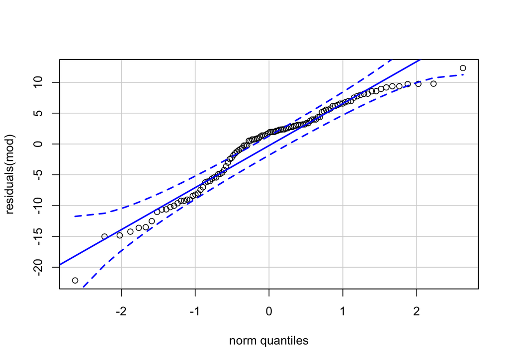

```r
qqPlot(residuals(mod),id=FALSE)
```

```r
shapiro.test(residuals(mod))
```

```
##
##  Shapiro-Wilk normality test
##
## data:  residuals(mod)
## W = 0.94867, p-value = 0.000226
```

Part of residuals fall within the dotted blue lines, and p-value is below 0.05. So the null hypothsis that errors are normally distributed is rejected. Errors are not normally distributed.